# Topics in Applied Econometrics - Assignment 1

Umut Demirhan - Student ID: 46739106

2023-08-28

### Abstract

# 1. Forecasting Median Price of Established House Transfers

## Introduction

This analysis aims to study the trends and fluctuations in the median price of established house transfers, utilizing data collected over a span of years, from 2002 to 2023. The study employs time-series analysis methods like ARIMA (AutoRegressive Integrated Moving Average) models, along with graphical visualizations, such as ACF (AutoCorrelation Function) and PACF (Partial AutoCorrelation Function) plots, to interpret underlying patterns.

## Data Import and Initial Exploration

### Importing the Data

```r
# Import the data
house <- read_abs(series_id = "A83728545T")
house_ts <- ts(house$value, start = c(2002,3),frequency = 4)
```

### Initial Data Plots

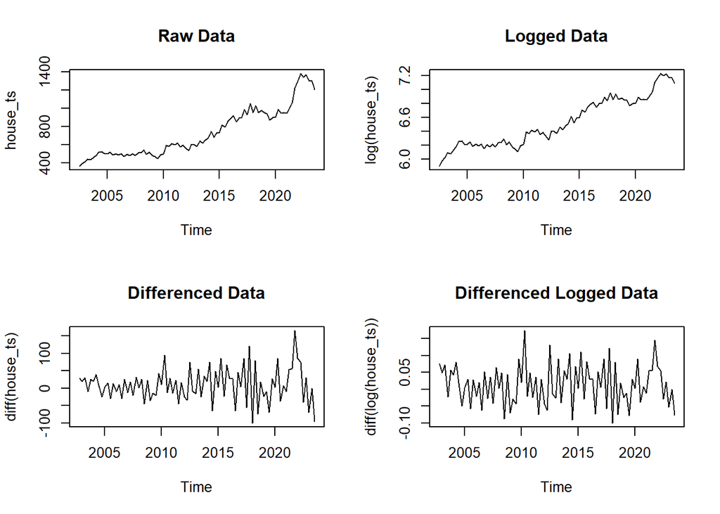

```r
par(mfrow=c(2,2))
plot(house_ts, main= "Raw Data")
plot(log(house_ts), main= "Logged Data")
plot(diff(house_ts), main= "Differenced Data")
plot(diff(log(house_ts)), main="Differenced Logged Data")
```

## Time-Series Diagnostics

### ACF and PACF Analysis

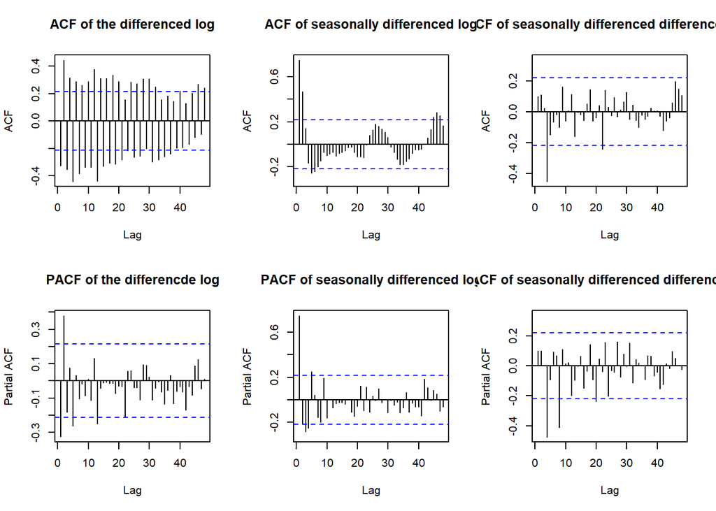

```r
par(mfrow=c(2,3))
Acf(diff(log(house_ts)), lag.max = 48, main= "ACF of the differenced log")
Acf(diff(log(house_ts),4), lag.max = 48, main= "ACF of seasonally differenced log")
Acf(diff(diff(log(house_ts)),4), lag.max = 48, main= "ACF of seasonally differenced differenced log")

Pacf(diff(log(house_ts)), lag.max = 48, main= "PACF of the differencde log")
Pacf(diff(log(house_ts),4), lag.max = 48, main= "PACF of seasonally differenced log")
Pacf(diff(diff(log(house_ts)),4), lag.max = 48, main= "PACF of seasonally differenced differenced log")
```

### Insights from ACF and PACF

The ACF and PACF plots for the median price of established house transfers indicate a non-stationary series with trend and seasonal components. These findings necessitate the use of an AR term and differencing for stationarity. ACF diagnostics on differenced log data suggest non-stationarity and seasonality, while seasonal differencing stabilizes ACF values. PACF in both cases advocates for a first-order AR term. Overall, these insights support the application of a Seasonal ARIMA model, specifically ARIMA(1,1,0)(1,1,0)[4], for robust forecasting.

## Model Estimation and Comparison of Models

```r
out.house <- Arima(log(house_ts), order = c(1,1,0),
             seasonal = list(order = c(1,1,0),
                             period = 4), include.constant = TRUE)

Auto.out <- auto.arima(log(house_ts), allowdrift=TRUE,
                       allowmean = TRUE, ic = "aic")

htmlreg(list(out.house, Auto.out),
                custom.model.names = c("ARIMA(1,1,0)(1,1,0)[4]", "ARIMA(3,1,0) with drift  model by auto.arima"),
                caption = "ARIMA Models Comparison",
                caption.above = TRUE,
                custom.note = "")
```

ARIMA Models Comparison

|  | ARIMA(1,1,0)(1,1,0)[4] | ARIMA(3,1,0) with drift model by auto.arima |
| --- | --- | --- |
| ar1 | 0.05 | -0.13 |
|  | (0.11) | (0.11) |
| sar1 | -0.47*** |  |
|  | (0.10) |  |
| ar2 |  | 0.34*** |
|  |  | (0.10) |
| ar3 |  | -0.18 |
|  |  | (0.11) |
| drift |  | 0.01* |
|  |  | (0.01) |
| AIC | -211.89 | -249.59 |
| AICc | -211.58 | -248.82 |
| BIC | -204.75 | -237.44 |
| Log Likelihood | 108.95 | 129.80 |
| Num. obs. | 80 | 84 |

The ‘auto.arima’ function suggests an ARIMA(3,1,0) model with a drift term for the log-transformed house prices data. This model shows a better fit than the previous ARIMA(1,1,0)(1,1,0)[4] model, as indicated by a lower AIC of -249.59 compared to -211.89. The ARIMA(3,1,0) model also includes a drift term, suggesting a small but consistent upward trend in the data.

## Model Validation

### Ljung–Box test

```r
# Box test for chosen model
box_test_house <- Box.test(out.house$residuals, lag=36, type= "Ljung-Box", fitdf=2)

# Box test for Auto ARIMA model
box_test_auto <- Box.test(Auto.out$residuals, lag=36, type= "Ljung-Box", fitdf=4)

# Combine results in a data frame
results <- data.frame(
  Model = c("ARIMA(1,1,0)(1,1,0)[4]","ARIMA(3,1,0) with drift  model by auto.arima"),
  Statistic = c(box_test_house$statistic, box_test_auto$statistic),
  p_value = c(box_test_house$p.value, box_test_auto$p.value)
)

# Print the table
kable(results, col.names = c("Model", "Ljung-Box Statistic", "p-value"))
```

| Model | Ljung-Box Statistic | p-value |
| --- | --- | --- |
| ARIMA(1,1,0)(1,1,0)[4] | 47.31008 | 0.0642499 |
| ARIMA(3,1,0) with drift model by auto.arima | 34.52919 | 0.3478592 |

Ljung-Box test results further support the model’s adequacy, with p-values above 0.05 indicating independently distributed residuals. Overall, the ARIMA(3,1,0) model is the better choice for capturing the data’s underlying patterns.

## Forecast with the Selected Model

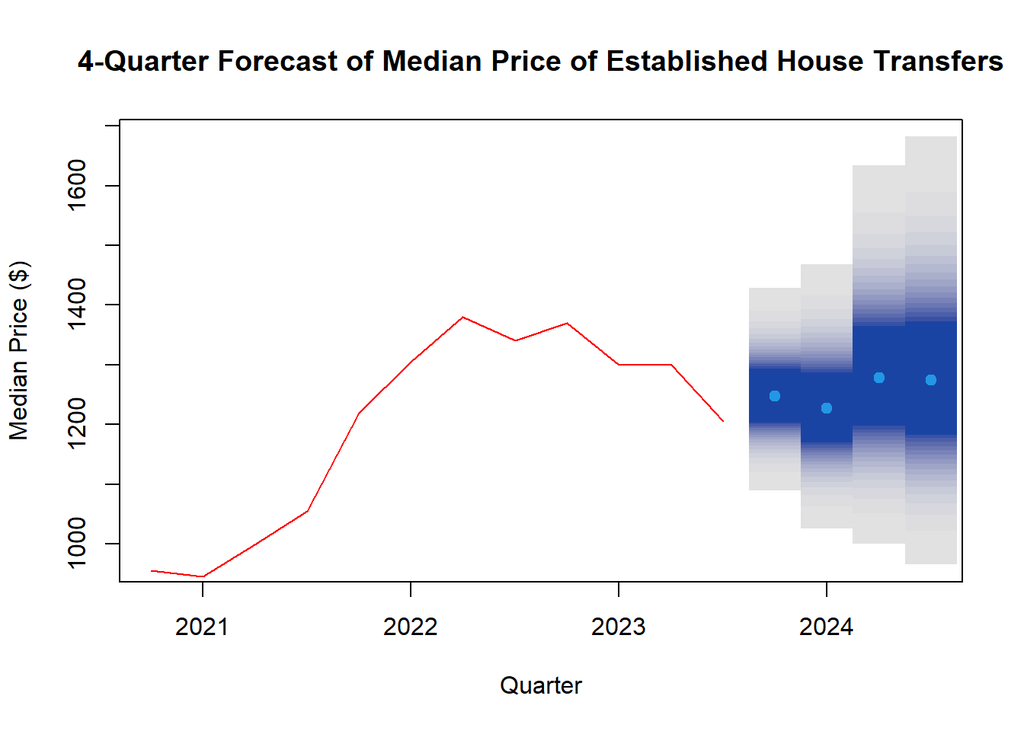

| Quarter | Forecasted Mean | Lower Bound | Upper Bound |
| --- | --- | --- | --- |
| 1 | 1247.54 | 1202.96 | 1297.10 |
| 2 | 1226.91 | 1169.19 | 1291.84 |
| 3 | 1278.45 | 1197.10 | 1371.66 |
| 4 | 1274.16 | 1182.83 | 1379.74 |

```r
fc.out <- forecast(Auto.out, h=4, fan = TRUE)
fc.out$x <- house_ts
fc.out$mean <- exp(fc.out$mean + Auto.out$sigma2/2)
fc.out$lower <- exp(fc.out$lower + Auto.out$sigma2/2)
fc.out$upper <- exp(fc.out$upper + Auto.out$sigma2/2)


# Plot the Forecast
plot(fc.out,
     include = 12,
     main="4-Quarter Forecast of Median Price of Established House Transfers",
     xlab="Quarter",
     ylab="Median Price ($)",
     col=rainbow(8),
     ylim=c(min(fc.out$lower), max(fc.out$upper)))
```

## Conclusion

In the analysis of the median price of established house transfers, the study employs time-series methods, specifically ARIMA models, to understand underlying trends and patterns from 2002 to 2023. ACF and PACF plots suggest a non-stationary series, necessitating differencing and the inclusion of an AutoRegressive (AR) term to achieve stationarity.

Two ARIMA models were examined: ARIMA(1,1,0)(1,1,0)[4] and ARIMA(3,1,0) with a drift term. The latter shows superior fit, as indicated by lower AIC and BIC values. Ljung-Box tests for both models confirm the independence of residuals, adding confidence to their predictive capabilities.

Statistical criteria, including AIC and BIC, are leveraged to evaluate model adequacy. The chosen ARIMA(3,1,0) model not only captures the complexities of the established house market but also provides a mathematically rigorous framework for future forecasts.

# 2. Forecasting COVID-19 cases admitted to Australian hospitals

## Introduction

This study aims to forecast weekly COVID-19 hospitalizations in Australia using time-series models. Given the absence of seasonal trends and a high degree of volatility in hospitalization rates, the analysis employs Autoregressive Integrated Moving Average (ARIMA) models to capture short-term dependencies and irregular patterns in the data.

## Data Import and Initial Exploration

### Importing the Data

```r
# Import the data
covid <- read.csv("covid_hospitalisations.csv")

# Create a time series object
covid_ts <- ts(covid$Hospitalisations, start=c(2022,36), frequency=52)
```

### Initial Data Plots

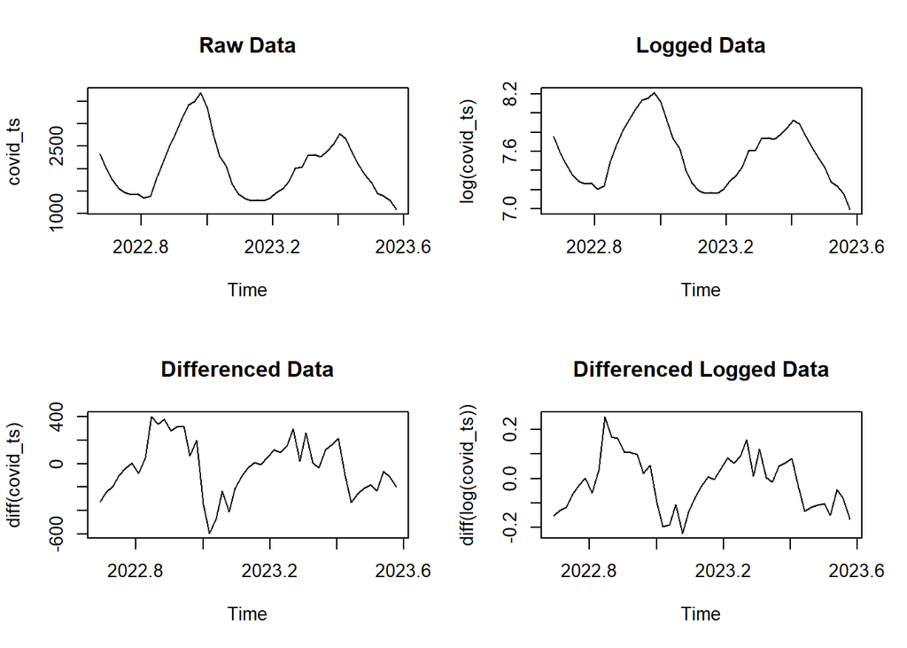

```r
par(mfrow=c(2,2))
plot(covid_ts, main= "Raw Data")
plot(log(covid_ts), main= "Logged Data")
plot(diff(covid_ts), main= "Differenced Data")
plot(diff(log(covid_ts)), main="Differenced Logged Data")
```

The sharp fluctuations in hospitalization rates for COVID-19 in Australia signal a high level of volatility. This complexity underscores the challenges in accurately predicting future hospitalization needs. Additionally, the absence of consistent seasonal patterns further complicates forecasting based on historical data alone, suggesting that simple seasonal models would likely fall short.Further complicating the analysis is the lack of any discernible long-term trend, either upward or downward, amplifying the uncertainty surrounding projections of future hospitalization rates.

## Time-Series Diagnostics

### ACF and PACF Analysis

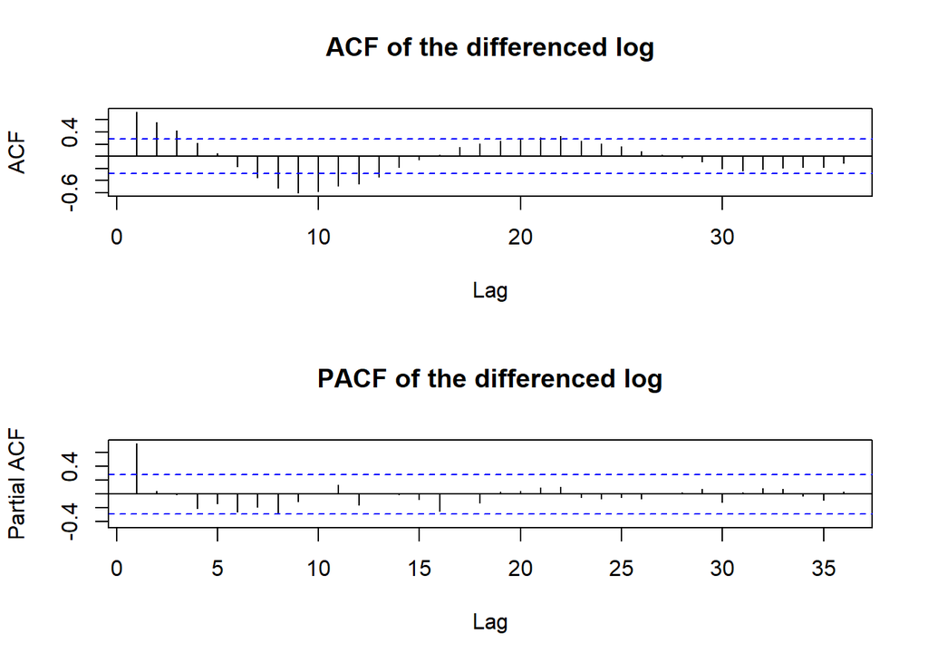

```r
par(mfrow=c(2,1))
Acf(diff(log(covid_ts)),lag.max = 36, main= "ACF of the differenced log")
Pacf(diff(log(covid_ts)),lag.max = 36, main= "PACF of the differenced log")
```

### Insights from ACF and PACF

The ACF and PACF plots for hospitalization data indicate short-term dependencies with the most significant influence at the first lag. The ACF suggests stationarity, and the PACF confirms the primary importance of the immediate past value. These findings point to an ARIMA model with parameters focused on short-term lags: AR term (p) at 1, Integrated term (d) at 0 or 1, and MA term (q) at 0 or 1. Initial models of ARIMA(1,0,1) or ARIMA(1,1,1) appear suitable for further testing.

## Model Estimation and Comparison of Models

ARIMA Models Comparison

|  | ARIMA(1,1,1) | ARIMA(2,0,1) model by auto.arima |
| --- | --- | --- |
| ar1 | 0.74*** | 1.85*** |
|  | (0.13) | (0.05) |
| ma1 | 0.03 | -0.52** |
|  | (0.18) | (0.19) |
| drift | -52.30 |  |
|  | (85.25) |  |
| ar2 |  | -0.94*** |
|  |  | (0.05) |
| intercept |  | 2064.01*** |
|  |  | (98.82) |
| AIC | 615.99 | 619.94 |
| AICc | 616.95 | 621.36 |
| BIC | 623.39 | 629.29 |
| Log Likelihood | -304.00 | -304.97 |
| Num. obs. | 47 | 48 |

## Model Validation

### Ljung–Box test

```r
# Box test for chosen model
box_test_covid <- Box.test(out.covid$residuals, lag=12, type= "Ljung-Box", fitdf=3)

# Box test for Auto ARIMA model
box_test_auto2 <- Box.test(Auto.out2$residuals, lag=36, type= "Ljung-Box", fitdf=3)

# Combine results in a data frame
results2 <- data.frame(
  Model = c("ARIMA(1,1,1)","ARIMA(2,0,1) model by auto.arima"),
  Statistic = c(box_test_covid$statistic, box_test_auto2$statistic),
  p_value = c(box_test_covid$p.value, box_test_auto2$p.value)
)

# Print the table
kable(results2, col.names = c("Model", "Ljung-Box Statistic", "p-value"))
```

| Model | Ljung-Box Statistic | p-value |
| --- | --- | --- |
| ARIMA(1,1,1) | 9.461737 | 0.3957879 |
| ARIMA(2,0,1) model by auto.arima | 25.655814 | 0.8152996 |

## Forecast with the Selected Model

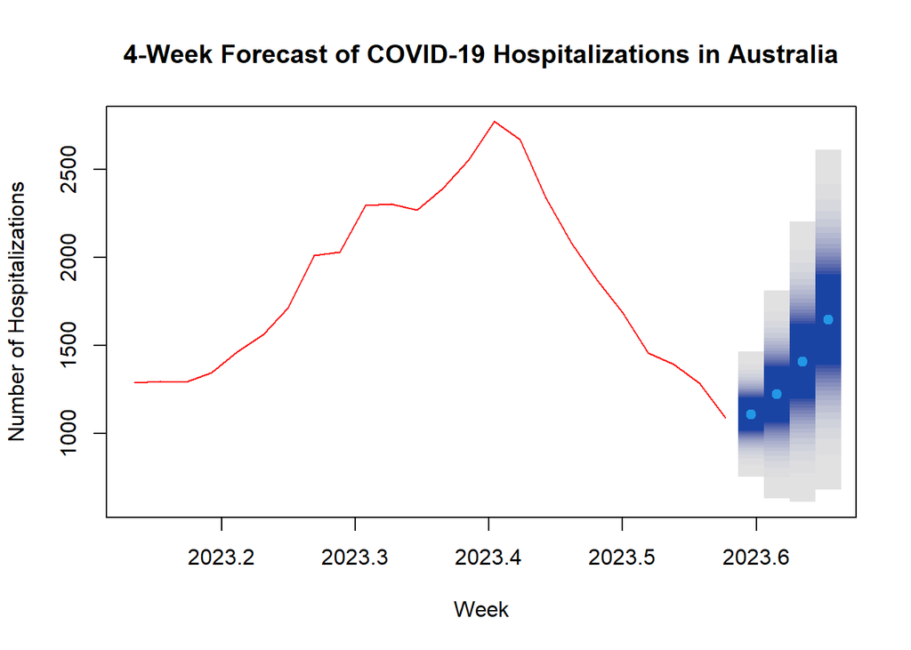

| Week | Forecasted Mean | Lower Bound | Upper Bound |
| --- | --- | --- | --- |
| 1 | 1109.57 | 1014.02 | 1211.85 |
| 2 | 1221.62 | 1063.20 | 1391.18 |
| 3 | 1408.18 | 1194.60 | 1636.78 |
| 4 | 1647.07 | 1388.68 | 1923.62 |

```r
fc.out2 <- forecast(Auto.out2, h=4, fan = TRUE)
fc.out2$x <- covid_ts

plot(fc.out2,
     include = 24,
     main="4-Week Forecast of COVID-19 Hospitalizations in Australia",
     xlab="Week",
     ylab="Number of Hospitalizations",
     col=rainbow(8))
```

# 3. Forecasting Industrial Production

## Introduction

This session addresses the time-series analysis of the Industrial Production Total Index, sourced from Federal Reserve Economic Data (FRED). The analysis employs data visualization, Autocorrelation and Partial Autocorrelation functions, and Seasonal ARIMA (SARIMA) models for both manual and automated configurations. Model performance is evaluated using metrics like AIC and the Ljung-Box test, followed by a forecasting exercise.

## Data Import and Initial Exploration

### Importing the Data

```r
# Import the data
library(fredr)
fredr_set_key("919ac488f169040b52e411572c0070b5")
production <- fredr(series_id = "IPB50001N")
# Create a time series object
production.ts <- ts(production$value, start = c(1919,1), frequency = 12)
```

### Initial Data Plots

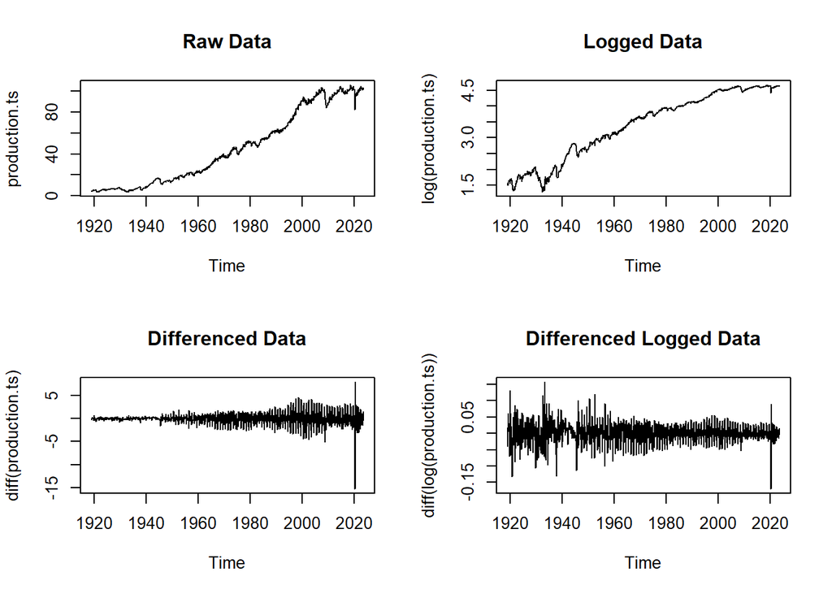

```r
par(mfrow=c(2,2))

plot(production.ts, main= "Raw Data")
plot(log(production.ts), main= "Logged Data")
plot(diff(production.ts), main= "Differenced Data")
plot(diff(log(production.ts)), main="Differenced Logged Data")
```

The production data exhibits a long-term upward trend that reached its peak in the early 2000s, followed by significant declines—most notably during the 2008 financial crisis and the COVID-19 pandemic in April 2020. The data also presents fluctuations that hint at seasonal effects. Transformation techniques, such as logarithms, help smooth these variations, while differencing the data centralizes fluctuations around zero. Although differencing reveals increased variability during crisis events, combining both logging and differencing mitigates this variability, making the data better suited for subsequent time series modeling.

## Time-Series Diagnostics

### ACF and PACF Analysis

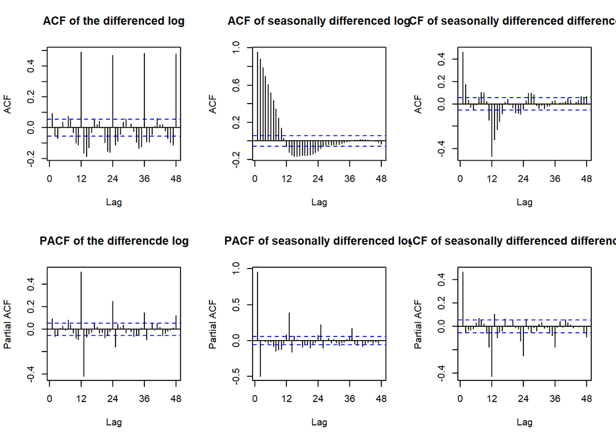

```r
par(mfrow=c(2,1))

par(mfrow=c(2,3))
Acf(diff(log(production.ts)), lag.max = 48, main= "ACF of the differenced log")
Acf(diff(log(production.ts),12), lag.max = 48, main= "ACF of seasonally differenced log")
Acf(diff(diff(log(production.ts)),12), lag.max = 48, main= "ACF of seasonally differenced differenced log")

Pacf(diff(log(production.ts)), lag.max = 48, main= "PACF of the differencde log")
Pacf(diff(log(production.ts),12), lag.max = 48, main= "PACF of seasonally differenced log")
Pacf(diff(diff(log(production.ts)),12), lag.max = 48, main= "PACF of seasonally differenced differenced log")
```

### Insights from ACF and PACF

The ACF and PACF plots for the differenced log data indicate a strong seasonal component with spikes at 12-month intervals. This suggests the applicability of a Seasonal ARIMA model. Specifically, the data hints at annual seasonality, calling for a seasonal differencing of order 1 (D=1). The ACF and PACF patterns also suggest a non-seasonal MA term of order 1 (q=1) and seasonal MA and AR terms at the 12th lag (Q=1, P=1). Thus, an initial SARIMA(0,1,1)(1,1,1)[12] model is recommended for further analysis.

## Model Estimation and Comparison of Models

```r
out.production <- Arima(log(production.ts), order = c(0,1,1), seasonal = list(order = c(1,1,1),
                             period = 12), include.constant = TRUE)

Auto.out3 <- auto.arima(log(production.ts), allowdrift=TRUE,
                       allowmean = TRUE, ic = "aic")

htmlreg(list(out.production, Auto.out3),
                custom.model.names = c("SARIMA(0,1,1)(1,1,1)[12]", "ARIMA(3,1,0)(2,0,0)[12] model by auto.arima"),
                caption = "ARIMA Models Comparison",
                caption.above = TRUE,
                custom.note = "")
```

ARIMA Models Comparison

|  | SARIMA(0,1,1)(1,1,1)[12] | ARIMA(3,1,0)(2,0,0)[12] model by auto.arima |
| --- | --- | --- |
| ma1 | 0.38*** |  |
|  | (0.02) |  |
| sar1 | -0.02 | 0.41*** |
|  | (0.04) | (0.03) |
| sma1 | -0.77*** |  |
|  | (0.03) |  |
| ar1 |  | 0.45*** |
|  |  | (0.03) |
| ar2 |  | -0.05 |
|  |  | (0.03) |
| ar3 |  | -0.03 |
|  |  | (0.03) |
| sar2 |  | 0.37*** |
|  |  | (0.03) |
| AIC | -6018.74 | -5942.87 |
| AICc | -6018.71 | -5942.80 |
| BIC | -5998.25 | -5912.07 |
| Log Likelihood | 3013.37 | 2977.44 |
| Num. obs. | 1242 | 1254 |

### Ljung–Box test

```r
# Box test for chosen model
box_test_production <- Box.test(out.production$residuals, lag=36, type= "Ljung-Box", fitdf=3)

# Box test for Auto ARIMA model
box_test_auto3 <-Box.test(Auto.out3$residuals, lag=36, type= "Ljung-Box", fitdf=3)

# Combine results in a data frame
results3 <- data.frame(
  Model = c("SARIMA(0,1,1)(1,1,1)[12]","ARIMA(3,1,0)(2,0,0)[12] model by auto.arima"),
  Statistic = c(box_test_production$statistic, box_test_auto3$statistic),
  p_value = c(box_test_production$p.value, box_test_auto3$p.value)
)

# Print the table
kable(results3, col.names = c("Model", "Ljung-Box Statistic", "p-value"))
```

| Model | Ljung-Box Statistic | p-value |
| --- | --- | --- |
| SARIMA(0,1,1)(1,1,1)[12] | 144.3625 | 0 |
| ARIMA(3,1,0)(2,0,0)[12] model by auto.arima | 170.6587 | 0 |

Both models display significant autocorrelation in their residuals up to 36 lags, suggesting that there may still be some information or patterns in the data that neither model has captured.

## Forecast with the Selected Model

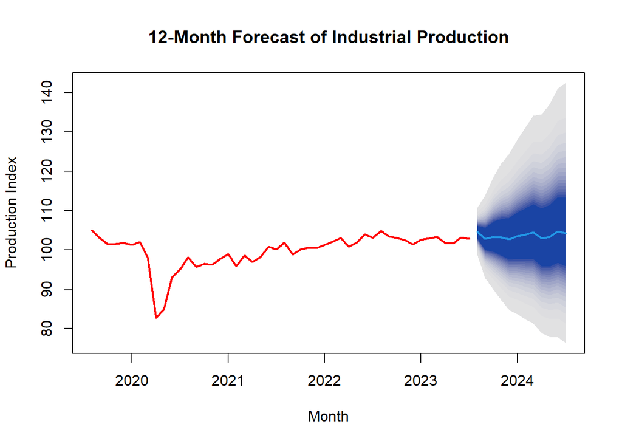

| Month | Forecasted Mean | Lower Bound | Upper Bound |
| --- | --- | --- | --- |
| 1 | 104.52 | 102.91 | 106.27 |
| 2 | 102.80 | 100.02 | 105.85 |
| 3 | 103.23 | 99.47 | 107.41 |
| 4 | 103.12 | 98.59 | 108.20 |
| 5 | 102.68 | 97.52 | 108.50 |
| 6 | 103.47 | 97.72 | 110.01 |
| 7 | 103.90 | 97.61 | 111.08 |
| 8 | 104.41 | 97.62 | 112.20 |
| 9 | 102.95 | 95.83 | 111.16 |
| 10 | 103.28 | 95.73 | 112.02 |
| 11 | 104.72 | 96.68 | 114.06 |
| 12 | 104.24 | 95.88 | 114.01 |

```r
fc.out3 <- forecast(Auto.out3, h=12, fan = TRUE)
fc.out3$x <- production.ts
fc.out3$mean <- exp(fc.out3$mean + Auto.out$sigma2/2)
fc.out3$lower <- exp(fc.out3$lower + Auto.out$sigma2/2)
fc.out3$upper <- exp(fc.out3$upper + Auto.out$sigma2/2)

plot(fc.out3, include = 48,
     main = "12-Month Forecast of Industrial Production",
     xlab = "Month",
     ylab = "Production Index",
      col=rainbow(8),
     lwd = c(2, 1, 1))
```